# DCHS technical SNP differences

Alexandre Lussier

2023-03-24

## Differences in SNPs between Illumina DNA methylation arrays

### Summary

This document outlines the differences in SNP probes between the 450K, EPICv1 and EPICv2 arrays. These differences were first identified when confirming sample matches across arrays.

### Dataset

This dataset is composed of blood DNAm profiles collected at age 5 for 30 participants from the Drakenstein Child Health Study (15F; 15M). DNAm for each participant was measured on the 450K, EPICv1, and EPICv2 arrays. Six replicates were included on the 450K array (36 samples total), and two replicated were included on the EPICv1 and EPICv2 arrays (32 samples each) for a total of 100 samples.

### Processing

Initial processing was performed using meffil 1.3.4 (Feb 24, 2023) - see DCHS_technical_preprocessing_clean_2023-03-22.Rmd. Only probes common between all three arrays were included in the processed dataset (57 unique SNPs).

### Main differences between arrays

#### Clustering of participants varies between arrays

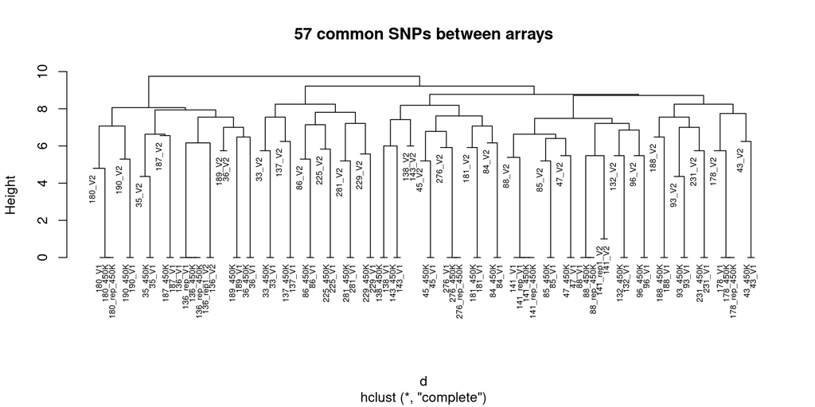

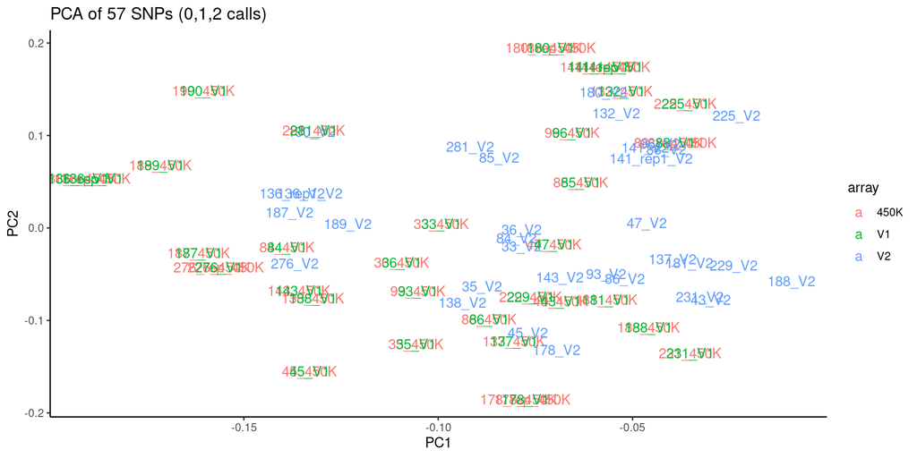

#### A subset of SNPs drives differences between arrays

Digging deeper into the differences between 450K/EPICv1 and EPICv2 samples reveals a subset of SNPs that tend to show differences between cohorts.

```
## These are the number of SNPs that are different between arrays
```

```
##     ID K450_V1 K450_V2
## 1  132       0       9
## 2  136       0      11
## 3  137       0      12
## 4  138       0      12
## 5  141       0      10
## 6  143       0      14
## 7  178       0       9
## 8  180       0       8
## 9  181       0      11
## 10 187       0      13
## 11 188       0      12
## 12 189       0      13
## 13 190       0       7
## 14 225       0      10
```

[output cut: 16 more lines]

```
## These are the 18 SNPs that are showing differences between arrays
```

```
##          rsID Number_participants
## 1   rs1040870                  18
## 2  rs10796216                  13
## 3  rs10882854                  23
## 4  rs10936224                  14
## 5  rs11034952                  17
## 6  rs13369115                  20
## 7   rs1520670                  15
## 8    rs213028                  16
## 9   rs2208123                  13
## 10  rs2385226                  11
## 11  rs3936238                  17
## 12  rs5926356                  24
## 13  rs5987737                  26
## 14  rs6471533                  13
## 15   rs654498                  12
## 16  rs6991394                  18
## 17   rs715359                  15
## 18  rs9292570                  21
```

#### What are these strange SNPs?

Investigating the SNPs that are different between arrays using the manifest file. It seems that the probes that don’t fully match in EPICv2 have issues with the color channel, next base, or probe sequence, which could explain why their genotype calls are slightly different from the 450K and EPICv1.

```
## Probes that don't match in EPICv2 are noted as problematic.
##
##     Probes that had no issues are noted as no issue.
```

```
## Checking whether the EPICv2 probe matches the 450K and EPICv1 probe (Manifest_probe_match):
```

```
##              Probe_match
##               Match Mismatch
##   No issue       36        3
##   Problematic     0       18
```

```
## Checking whether the EPICv2 Color Channel matches the 450K and EPICv1 probe:
```

```
##              Color_channel
##               Match Mismatch
##   No issue       39        0
##   Problematic    13        5
```

```
## Checking whether the EPICv2 Next Base matches the 450K and EPICv1 probe:
```

```
##              Next_Base
##               Match Mismatch
##   No issue       39        0
##   Problematic    12        6
```

```
## Number of probes with all bad metrics:
```

```
##              Metrics_all
##               Bad Good
##   No issue      0   39
##   Problematic   5   13
```

```
## Number of probes with any bad metrics:
```

```
##              Metrics_any
##               Bad Good
##   No issue      3   36
##   Problematic  18    0
```

These look like potential filtering metrics, resulting in 36 SNPs that are without major issues (21 removed).

```
## Here are the SNPs to remove for future reference:
```

```
##  [1] "rs10033147" "rs1040870"  "rs10796216" "rs10882854" "rs10936224"
##  [6] "rs11034952" "rs13369115" "rs1520670"  "rs213028"   "rs2208123"
## [11] "rs2385226"  "rs3936238"  "rs5926356"  "rs5987737"  "rs6471533"
## [16] "rs654498"   "rs6626309"  "rs6991394"  "rs715359"   "rs9292570"
## [21] "rs951295"
```

#### Removing the bad SNPs

Now that the bad SNPs are removed, we can check whether the samples cluster together and are identical.

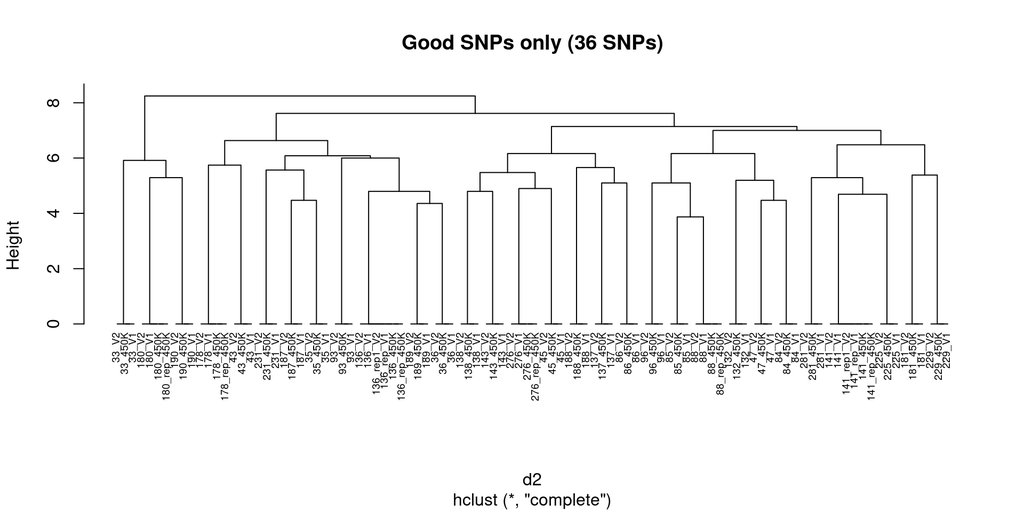

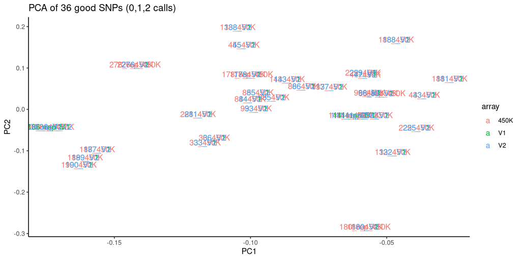

```
## Are the samples identical?
```

```
##     ID K450_V1 K450_V2
## 1  132       0       0
## 2  136       0       0
## 3  137       0       0
## 4  138       0       0
## 5  141       0       0
## 6  143       0       0
## 7  178       0       0
## 8  180       0       0
## 9  181       0       0
## 10 187       0       0
## 11 188       0       0
## 12 189       0       0
## 13 190       0       0
## 14 225       0       0
```

[output cut: 16 more lines]

```
## Yes they are!
```

### Conclusions

There are several SNP probes on the EPICv2 that have poor performance, resulting in sample mismatches at the SNP level. These should generally be filtered to avoid errors in SNP matching.